# Grip strength, mating success, and immune function in US adults: a registered report

C. B. Smith and E. H. Hagen

03/23/2023

EHB Research Report

## Abstract

1.1 Sexual dimorphism in modern humans:

Whether modern human sexual size dimorphism is inherited or derived remains debated (Plavcan, 2012). Sexual dimorphism refers to sex differences in morphological and behavioral traits, excluding reproductive organs (Plavcan, 2001). Sexual size dimorphism in humans begins in the first trimester in utero where male embryos measure larger than female (Bukowski et al., 2007). Newborn boys are more likely to be larger for gestational age than female newborns, while female newborns exhibit higher average skinfold difference and higher relative fat mass. However, no sex typical differences in stature are observed during early childhood and the prepubertal period. In adults, there is a difference of between 12 and 25% in body mass (Lassek & Gaulin, 2022). Humans are slightly more dimorphic in body mass than gibbons, but slightly less than chimpanzees (Smith & Jungers, 1997). A modest 7-8% height dimorphism in humans, a reduction from ancestral species (Gray & Wolf, 1980; Gaulin & Boster, 1985). Other traits that are dimorphic in humans include digit ratio, voice pitch, facial features, and canine length.

While humans are only moderately dimorphic in terms of overall body mass, this is not the case of allocation of fat and muscle, which are highly dimorphic (Puts, 2010). This is partly due to women’s copious storage of fat, unique among primates. Human males have between 30 and 42% more fat free mass (Lassek & Gaulin, 2022). On average, men have 61% more overall muscle mass and 78% more muscle mass in the upper arms. This concentrated muscle dimorphism in the arms and back translates to 90% greater upper body strength in men than women (Lassek & Gaulin, 2009). This difference in muscle and strength is not accounted for by size difference alone (Lassek & Gaulin, 2022).

1.2 Sexual dimorphism hypotheses

1.2.1 Intrasexual selection: male-male competition

The intrasexual selection hypothesis emphasizes evidence that female mate choice was limited in the ancestral past (Puts, 2010), and argues that many masculine traits, including aggression, large body size, and strength, are best explained by an evolutionary history of contest competition for mate access (Puts, 2016, Hill et al., 2017). They argue that intrasexual selection due to an evolutionary history of male-male contests is the most parsimonious explanation for the constellation of sexually dimorphic traits in humans, while acknowledging that some degree of sexual size dimorphism could have been inherited from an ancestral species.

Masculine traits including, increased musculature, could arise through male-male competition if formidable men were more successful at attaining resources and mates, either directly through physical contests or indirectly. It also could be the case that female choice still plays a role if women preferentially mate with more formidable men. While it could be the case that female choice still plays a role in selection for masculine traits, proponents of this hypothesis point to evidence that mating success due to formidability is better explained by male-rated dominance and not their attractiveness to women.

Sexual dimorphism in formidability is taken as evidence of sexual selection, as larger size or strength, typically in males, indicates competition for access to mates. In extant primate species, sexual dimorphism in body weight and canine size are strongly associated with degree of intrasexual competition, and the same relationship is used to infer the sexual behavior of extinct australopithecines (Plavcan & van Shaik, 1997). Furthermore, contests override other mechanisms of sexual selection, because when males can exclude other males from mating opportunities mate choice and sperm competition become irrelevant (Puts, 2010).

1.2.2 The immunocompetence handicap hypothesis

In contrast to the intra-sexual selection hypothesis, others argue that sexual dimorphism in humans is largely the result of female choice, not for more formidable or competitive men, but for immunocompetent men. The immunocompetence handicap hypothesis relies on evidence that testosterone is immunosuppressive, and therefore only men with highly competent immune systems can afford to pay the costs of high levels of testosterone required to develop masculine traits. Therefore, masculine traits like strength, could be costly signals of good genetic quality, and masculine men should produce higher quality offspring (Folstad & Karter, 1992). Under this hypothesis, masculine traits arise through female choice if females preferentially choose to mate with males displaying these traits indicating heritable phenotypic quality, therefore passing those traits to their offspring. A few major problems arise for this hypothesis. First, evidence that testosterone is actually immunosuppressive is mixed (Nowak et al., 2018). Secondly, it is unclear to what extent women are attracted to testosterone-dependent traits, for instance facial masculinity.

Strength and reproductive success

Previous research has shown that greater muscle mass in males predicts numbers of total and past-year self-reported sex partners, but that it also involves costs such as increased daily energy intake and decreased immune function (C-reactive protein and white blood cell count) (Lassek & Gaulin, 2009), consistent with a tradeoff in mating success and immunity. However, these relationships were not tested in women, where the sexual selection hypothesis predicts no association. We plan to expand these analyses to include women using a different proxy for muscle mass, grip strength.

1.3 Experimental aims and hypotheses

Based on results from exploratory analyses, we predict:

1. Strength will be positively related to the number of self-reported heterosexual sex partners, both total and past year, and negatively related to the age of first intercourse for both men and women.
2. Strength will be positively related to currently partnered status for both men and women.
3. Strength will be negatively related to white blood cell count, a measure of native immunity for both men and women.

We will also control for a range of potential confounds including anthropometric, socioeconomic, hormone, health, and physical activity.

## Methods

To assess the relationship between strength and reproductive and immune outcomes we used data from the Centers for Disease Control National Health and Nutrition Examination Survey (NHANES) from years 2011-2014. NHANES uses a complex, multi-stage sampling strategy in order to collect data representative of the civilian, non-institutionalized U.S. population. NHANES combines interview, examination, and laboratory data to assess health status and identify health risks for adults and children in the United States. Data collection occurs in new cycles every two years.

### Outcome variables:

In industrialized populations like the U.S., widespread access to contraceptives unlinks reproductive success from sexual behavior. Measures of mating success, including number of sexual partners and age at first sexual intercourse, are used as proxies as they are assumed to have been strongly correlated with reproductive success under ancestral conditions (Pérusse, 1993).Our main outcome was mating success, which we operationalized in three ways. 1) Total sexual partners was a count based on responses to the question: In your lifetime, with how many men/women have you had any kind of sex? 2) Total sexual partners in past year, from the question: In the past 12 months, with how many men/women have you had any kind of sex? Because of the way these questions are framed, (e.g. female participants were asked about their male partners and vice versa) these variables represent heterosexual partners, however it is not necessarily the case that all of the participants included in these models identified as heterosexual. 3) Age at first sexual intercourse reported from: How old were you when you had sex for the first time?. The sexual behavior questionnaire was self-administered on a computer in a private room at the examination center, using the Audio Computer Assisted Self Interview system, which allows participants to hear questions through headphones as well as read them on screen. Only respondents who could self-report were asked these questions.

Our second outcome measure was immune investment, which we operationalized as white blood cell count (1000 cells/ µL). In the original paper, Lassek and Gaulin also use C-reactive protein, but CRP was not measured in the 2011-2014 data collection years and so is not included here.

### Predictor variables:

Our main predictor variable is formidability, which Lassek and Gaulin operationalized as fat-free mass and limb muscle volume. We operationalized formidability as grip strength (kg), which was measured three times on each hand using a dynamometer. We used combined grip strength which was the sum of the highest reading of each hand. All models also included sex (male/female), age in years, partnered status (partnered included participants who reported either being married or living with a partner while unpartnered included participants who reported being single, widowed, divorced, or separated). The interaction between sex and strength was crucial for our models since we want to know whether the effect of strength on mating and immune outcomes is different for women than for men. Likewise, we also interacted age and partnered status with sex.

### Models:

We specified five models for each mating success outcome measure in order to determine if the effect of grip strength on those outcomes was due to confounds with socioeconomic, health, hormone, or physical activity variables that have been associated either with strength or sexual behavior.

#### Baseline (anthropometric) model

We first derived a simple baseline model from Lassek and Gaulin (2009) for each outcome measure (total number of partners, past year number of partners, and age at first intercourse) predicted by grip strength, age, sex, This model also includes an anthropometric control, body mass index (BMI), calculated as kg/m^2, since body size could be related to either strength or mating outcomes.

#### Additional control variables:

The socioeconomic control model included education and race as categorical variables. The health model included a number of variables related to health, which could affect either strength or sexual behavior. White blood cell count (1000 cells/ µL) and hemoglobin (g/dL) were included to control for acute infection. Depression was measured using the Patient Health Questionnaire-9 (PHQ-9), a validated nine-item screening instrument. Each item represents a symptom of depression, and for each participants were asked to consider how frequently they had been bothered by that symptom over the past two weeks, rated on a scale from 0 (not at all) to 3 (nearly everyday). These ratings were summed to produce a depression score ranging from 0-27. Chronic illness was included using a ‘chronic disease score (0-6) a count of chronic diseases participants reported having been diagnosed with including diabetes, cancer, stroke, arthritis, heart disease and respiratory disease. A point was added for each disease a participant indicated they had been diagnosed with, regardless of any impairment due to the disease. We then controlled for impairment resulting from chronic illness (Disease Impairment Score; 0-5) calculated from a different NHANES question, which asked participants to list up to five health conditions that specifically cause them to have difficulties with physical activities. We also controlled for physical disability and using the item “special equipment” which referred to participants’ report that they needed special equipment to walk. Finally the ‘perceived abnormal weight’ variable was coded as true or false depending on whether a participant reported that they perceived their weight to be abnormal.

The hormone control model included testosterone. Since the difference in mean testosterone between men and women is an order of magnitude apart, and testosterone was highly confounded with sex. We therefore centered testosterone at the mean and divided by two standard deviations within each sex. The physical activity control model included four dichotomous variables coded as 1 if participants reported that their work or recreation caused large increases in heart rate or breathing for at least 10 minutes continuously (vigorous work and/or rec), or small increases in breathing or heart rate for 10 minutes continuously (moderate work and/or rec), and zero if they did not.

We did not include a model of daily energy intake as reported by Lassek and Gaulin, because the gold-standard research utilizes fat-free mass as a predictor, which the original authors use. Grip strength is therefore unlikely to provide novel insight into explaining daily energy intake.

#### Analysis

Lassek and Gaulin (2009) utilized stepwise regression to automatically eliminate candidate predictors from their models. Since stepwise regression has since been found to overfit data and therefore fail to replicate in future samples, we use generalized linear models from the survey package to incorporate survey weights. For models of lifetime and past year numbers of partners we modeled the outcomes using a poisson distribution, since these variables are count data. Models of age at first sexual intercourse and white blood cell count utilized a normal distribution. Analyses include adults ages 18-59 because this is period when the majority of reproduction takes place and because these are the years when grip strength is the most stable.

### 3. Results: Exploratory Analysis

#### 3.1 Descriptive statistics

Table one shows weighted means and standard deviations of all variables for men and women ages 18-59. Mean age was 38 years for this sample. Sexual dimorphism is given as a ration of male mean:female mean. Larger male size dimorphism is reflected in 8% for height and 16% for weight, females, however had a 1% higher BMI than males on average. There is a much larger difference in the dimorphism in combined grip strength (57%).

Hemoglobin is higher in males than females (14%), driven separately by an inhibitory effect of estrogen and stimulatory effect of androgens, possibly the result of selection on diverting resources that would otherwise be used to increase hemoglobin levels to the male mean to offspring instead (Murphy, 2014). White blood cell count, however, is 3% higher in women.

**Table 1. Sex differences based on Lassek and Gaulin Table 1 for ages 18-59**

| **Variable** | **male** **N** | **male** **Mean** | **male** **SD** | **female** **N** | **female** **Mean** | **female** **SD** | **Sexual dimorphism** **Ratio** | **Sexual dimorphism** **d** |
| --- | --- | --- | --- | --- | --- | --- | --- | --- |
| Age (years) | 2,011 | 36.99 | 12.4 | 2,062 | 37.73 | 12.3 | 0.98 | -0.06 |
| Height (cm) | 1,921 | 175.06 | 7.49 | 1,963 | 161.73 | 7.20 | 1.08 | 1.81 |
| Weight (kg) | 1,920 | 86.28 | 21.5 | 1,961 | 76.04 | 21.6 | 1.13 | 0.48 |
| Body mass index (kg/m^2) | 1,919 | 28.07 | 6.35 | 1,960 | 29.03 | 7.81 | 0.97 | -0.13 |
| Combined Grip Strength (kg) | 1,773 | 91.99 | 17.4 | 1,733 | 58.50 | 10.8 | 1.57 | 2.31 |
| White blood cell count (1000 cells/µL) | 1,830 | 6.90 | 2.07 | 1,896 | 7.11 | 2.14 | 0.97 | -0.10 |
| Hemoglobin (g/dL) | 1,830 | 14.97 | 1.13 | 1,896 | 13.02 | 1.26 | 1.15 | 1.62 |
| Testosterone (ng/dL) | 1,768 | 416.55 | 176 | 1,821 | 25.83 | 22.5 | 16.13 | 3.13 |

**Table 1. Sex differences based on Lassek and Gaulin Table 1 for ages 18-49**

| **Variable** | **male** **N** | **male** **Mean** | **male** **SD** | **female** **N** | **female** **Mean** | **female** **SD** | **Sexual dimorphism** **Ratio** | **Sexual dimorphism** **d** |
| --- | --- | --- | --- | --- | --- | --- | --- | --- |
| Age (years) | 1,576 | 32.22 | 9.41 | 1,584 | 32.81 | 9.43 | 0.98 | -0.06 |
| Height (cm) | 1,506 | 175.37 | 7.49 | 1,507 | 162.19 | 7.13 | 1.08 | 1.80 |
| Weight (kg) | 1,505 | 86.10 | 21.7 | 1,505 | 75.35 | 21.9 | 1.14 | 0.49 |
| Body mass index (kg/m^2) | 1,504 | 27.92 | 6.44 | 1,505 | 28.59 | 7.84 | 0.98 | -0.09 |
| Combined Grip Strength (kg) | 1,393 | 93.82 | 17.2 | 1,327 | 59.55 | 10.7 | 1.58 | 2.37 |
| White blood cell count (1000 cells/µL) | 1,433 | 6.88 | 2.07 | 1,457 | 7.22 | 2.16 | 0.95 | -0.16 |
| Hemoglobin (g/dL) | 1,433 | 15.03 | 1.09 | 1,457 | 12.94 | 1.26 | 1.16 | 1.78 |
| Testosterone (ng/dL) | 1,386 | 422.67 | 175 | 1,406 | 27.68 | 22.7 | 15.27 | 3.18 |

**Table 1. Sex differences based on Lassek and Gaulin Table 1 for ages 18-59 using population weights**

| **Characteristic** | **N** | **Male** **male**, N = 88,509,275<sup>1</sup> | **Male** **SD** | **Female** **female**, N = 89,488,954<sup>1</sup> | **Female** **SD** | **Ratio** | **Difference**<sup>2</sup> |  |  |
| --- | --- | --- | --- | --- | --- | --- | --- | --- | --- |
| Age (years) | 177,998,229 | 38.93 | 12.72 | 39.19 | 12.31 |  |  | 0.99 | -0.02 |
| Height (cm) | 176,691,079 | 176.26 | 7.60 | 162.84 | 7.21 | 1.08 | 1.8 |  |  |
| Weight (kg) | 176,592,245 | 88.45 | 20.30 | 76.42 | 20.67 | 1.16 | 0.59 |  |  |
| Body mass index (kg/m^2) | 176,539,855 | 28.43 | 6.06 | 28.82 | 7.59 | 0.99 | -0.06 |  |  |
| Combined Grip Strength (kg) | 161,169,394 | 93.04 | 17.11 | 59.20 | 10.46 | 1.57 | 2.4 |  |  |
| White blood cell count (1000 cells/µL) | 171,390,380 | 6.94 | 2.03 | 7.19 | 2.09 | 0.97 | -0.12 |  |  |
| Hemoglobin (g/dL) | 171,390,380 | 15.12 | 1.09 | 13.28 | 1.16 | 1.14 | 1.6 |  |  |
| Testosterone (ng/dL) | 165,955,614 | 410.86 | 170.54 | 25.73 | 23.25 | 15.97 | 3.2 |  |  |

<sup>1</sup> Mean  
<sup>2</sup> Standardized Mean Difference

**Table 1. Participant Characteristics for all variables**

| **Variable** | **N** | **Sex** **male**, N = 2,011<sup>1</sup> | **Sex** **female**, N = 2,062<sup>1</sup> |
| --- | --- | --- | --- |
| Lifetime number of sexual partners | 3,297 | 20.53 (79.65) | 8.06 (21.97) |
| Missing |  | 332 | 444 |
| Past year number of sexual partners | 3,314 | 1.65 (3.10) | 1.13 (1.81) |
| Missing |  | 321 | 438 |
| Age at first sex (years) | 3,135 | 17.11 (4.11) | 17.62 (3.82) |
| Missing |  | 427 | 511 |
| Combined Grip Strength (kg) | 3,506 | 91.99 (17.37) | 58.50 (10.76) |
| Missing |  | 238 | 329 |
| Age (years) | 4,073 | 36.99 (12.40) | 37.73 (12.27) |
| Partnered | 3,767 | 1,066 / 1,854 (57%) | 1,074 / 1,913 (56%) |
| Missing |  | 157 | 149 |
| Body mass index (kg/m^2) | 3,879 | 28.07 (6.35) | 29.03 (7.81) |
| Missing |  | 92 | 102 |
| Education | 4,073 |  |  |
| Less than 9th grade |  | 130 / 2,011 (6.5%) | 117 / 2,062 (5.7%) |
| 9-11th grade |  | 329 / 2,011 (16%) | 284 / 2,062 (14%) |
| High school graduate/GED or equivalent |  | 469 / 2,011 (23%) | 393 / 2,062 (19%) |
| Some college or AA degree |  | 615 / 2,011 (31%) | 694 / 2,062 (34%) |
| College graduate or above |  | 468 / 2,011 (23%) | 574 / 2,062 (28%) |
| Race and Ethnicity | 4,073 |  |  |
| Mexican American |  | 243 / 2,011 (12%) | 221 / 2,062 (11%) |
| Other Hispanic |  | 180 / 2,011 (9.0%) | 222 / 2,062 (11%) |
| Non-Hispanic White |  | 695 / 2,011 (35%) | 661 / 2,062 (32%) |
| Non-Hispanic Black |  | 505 / 2,011 (25%) | 567 / 2,062 (27%) |
| Non-Hispanic Asian |  | 314 / 2,011 (16%) | 331 / 2,062 (16%) |
| Other Race |  | 74 / 2,011 (3.7%) | 60 / 2,062 (2.9%) |
| White blood cell count (1000 cells/µL) | 3,726 | 6.90 (2.07) | 7.11 (2.14) |
| Missing |  | 181 | 166 |
| Hemoglobin (g/dL) | 3,726 | 14.97 (1.13) | 13.02 (1.26) |
| Missing |  | 181 | 166 |
| Depression Score (0-27) | 3,380 | 2.80 (4.14) | 3.81 (4.82) |
| Missing |  | 289 | 404 |
| Chronic Disease Score (0-6) | 3,751 | 0.38 (0.65) | 0.51 (0.79) |
| Missing |  | 166 | 156 |
| Disease Impairment Score (0-5) | 4,072 | 0.23 (0.76) | 0.31 (0.92) |
| Missing |  | 0 | 1 |
| Special equipment needed to walk | 3,768 | 79 / 1,854 (4.3%) | 107 / 1,914 (5.6%) |
| Missing |  | 157 | 148 |
| Perceived abnormal weight | 4,061 | 956 / 2,003 (48%) | 1,274 / 2,058 (62%) |
| Missing |  | 8 | 4 |
| Testosterone (ng/dL) | 3,589 | 416.55 (176.12) | 25.83 (22.48) |
| Missing |  | 243 | 241 |
| Work involves vigorous activity | 4,073 | 533 / 2,011 (27%) | 207 / 2,062 (10%) |
| Recreation involves vigorous activity | 4,073 | 769 / 2,011 (38%) | 459 / 2,062 (22%) |
| Work involves moderate activity | 4,073 | 777 / 2,011 (39%) | 590 / 2,062 (29%) |
| Recreation involves moderate activity | 4,073 | 910 / 2,011 (45%) | 924 / 2,062 (45%) |

<sup>1</sup> Mean (SD); n / N (%)

**Table 1. Participant Characteristics for all variables using population weights**

| **Variable** | **N** | **Sex** **male**, N = 88,509,275<sup>1</sup> | **Sex** **female**, N = 89,488,954<sup>1</sup> |
| --- | --- | --- | --- |
| Lifetime number of sexual partners | 154,788,464 | 22.17 (85.56) | 8.79 (21.30) |
| Missing |  | 9,399,242 | 13,810,524 |
| Past year number of sexual partners | 152,232,505 | 1.50 (2.88) | 1.10 (2.05) |
| Missing |  | 11,014,874 | 14,750,850 |
| Age at first sex (years) | 149,595,371 | 17.15 (3.90) | 17.45 (3.46) |
| Missing |  | 12,463,908 | 15,938,950 |
| Combined Grip Strength (kg) | 161,169,394 | 93.04 (17.11) | 59.20 (10.46) |
| Missing |  | 6,799,676 | 10,029,159 |
| Age (Years) | 177,998,229 | 38.93 (12.72) | 39.19 (12.31) |
| Partnered | 169,962,580 | 49,915,636 / 83,801,688 (60%) | 52,921,743 / 86,160,892 (61%) |
| Missing |  | 4,707,587 | 3,328,062 |
| Body mass index (kg/m^2) | 176,539,855 | 28.43 (6.06) | 28.82 (7.59) |
| Missing |  | 400,312 | 1,058,062 |
| Education | 177,998,229 |  |  |
| 1 |  | 4,341,291 / 88,509,275 (4.9%) | 3,675,364 / 89,488,954 (4.1%) |
| 2 |  | 11,428,131 / 88,509,275 (13%) | 9,190,348 / 89,488,954 (10%) |
| 3 |  | 20,044,761 / 88,509,275 (23%) | 15,849,989 / 89,488,954 (18%) |
| 4 |  | 27,925,804 / 88,509,275 (32%) | 31,390,266 / 89,488,954 (35%) |
| 5 |  | 24,769,288 / 88,509,275 (28%) | 29,382,988 / 89,488,954 (33%) |
| Race and Ethnicity | 177,998,229 |  |  |
| MexicanAmerican |  | 8,796,243 / 88,509,275 (9.9%) | 8,021,624 / 89,488,954 (9.0%) |
| OtherHispanic |  | 6,284,292 / 88,509,275 (7.1%) | 6,705,224 / 89,488,954 (7.5%) |
| NonHispanicWhite |  | 56,208,583 / 88,509,275 (64%) | 54,917,683 / 89,488,954 (61%) |
| NonHispanicBlack |  | 10,092,194 / 88,509,275 (11%) | 12,271,642 / 89,488,954 (14%) |
| NonHispanicAsian |  | 4,594,470 / 88,509,275 (5.2%) | 5,221,748 / 89,488,954 (5.8%) |
| OtherRace |  | 2,533,494 / 88,509,275 (2.9%) | 2,351,033 / 89,488,954 (2.6%) |
| White blood cell count (1000 cells/µL) | 171,390,380 | 6.94 (2.03) | 7.19 (2.09) |
| Missing |  | 3,522,973 | 3,084,876 |
| Hemoglobin (g/dL) | 171,390,380 | 15.12 (1.09) | 13.28 (1.16) |
| Missing |  | 3,522,973 | 3,084,876 |
| Depression Score (0-27) | 157,893,564 | 2.76 (4.13) | 3.51 (4.57) |
| Missing |  | 7,623,992 | 12,480,673 |
| Chronic Disease Score (0-6) | 168,873,214 | 0.40 (0.66) | 0.54 (0.82) |
| Missing |  | 5,306,808 | 3,818,207 |
| Disease Impairment Score (0-5) | 177,976,579 | 0.21 (0.69) | 0.27 (0.83) |
| Missing |  | 0 | 21,650 |
| Special equipment needed to walk | 169,940,930 | 2,534,447 / 83,801,688 (3.0%) | 3,945,778 / 86,139,242 (4.6%) |
| Missing |  | 4,707,587 | 3,349,712 |
| Perceived abnormal weight | 177,549,560 | 45,215,094 / 88,292,343 (51%) | 56,668,108 / 89,257,216 (63%) |
| Missing |  | 216,932 | 231,738 |
| Testosterone (ng/dL) | 165,955,614 | 410.86 (170.54) | 25.73 (23.25) |
| Missing |  | 5,834,154 | 6,208,460 |
| Work involves vigorous activity | 177,998,229 | 26,583,425 / 88,509,275 (30%) | 10,224,931 / 89,488,954 (11%) |
| Recreation involves vigorous activity | 177,998,229 | 32,548,398 / 88,509,275 (37%) | 22,240,837 / 89,488,954 (25%) |
| Work involves moderate activity | 177,998,229 | 37,490,844 / 88,509,275 (42%) | 28,878,167 / 89,488,954 (32%) |
| Recreation involves moderate activity | 177,998,229 | 42,706,882 / 88,509,275 (48%) | 44,981,890 / 89,488,954 (50%) |

<sup>1</sup> Mean (SD); n / N (%)

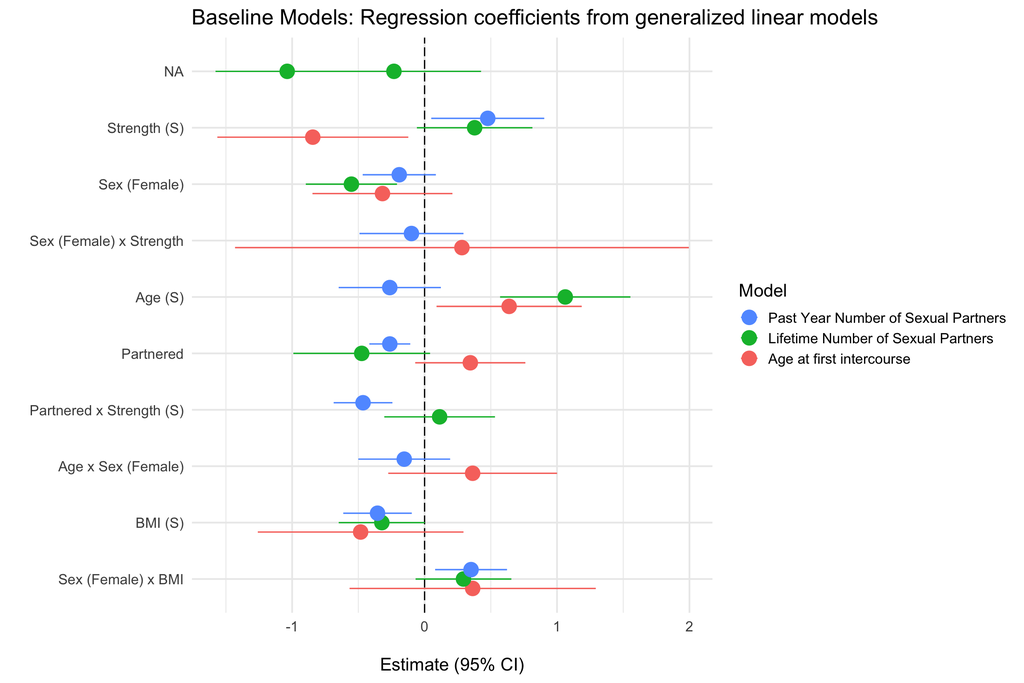

We did not include an interaction between CGS and partnered status for models of age at first sex since, for the majority of participants their age at first sex was not in the recent past and unlikely to be predicted by current grip strength or current partnered status.

Table 2. Baseline Models of Mating Success

Standardized regression coefficents from generalized linear models for three indices of mating success for men and women ages 18-59. Models derived from Lassek and Gaulin 2009

| **Variable** | Lifetime number of sexual partners **Beta (SE)**<sup>1,2</sup> | Past year number of sexual partners **Beta (SE)**<sup>1,2</sup> | Age at first sexual intercourse **Beta (SE)**<sup>1,2</sup> |
| --- | --- | --- | --- |
| Grip strength | 0.38 (0.189) | 0.48* (0.185) | -0.84* (0.319) |
| Sex |  |  |  |
| male | — | — | — |
| female | -0.55** (0.149) | -0.19 (0.120) | -0.32 (0.233) |
| Age | 1.1** (0.213) | -0.26 (0.167) | 0.64* (0.242) |
| Currently partnered |  |  |  |
| FALSE | — | — | — |
| TRUE | -0.47 (0.224) | -0.26** (0.067) | 0.35 (0.184) |
| BMI | -0.32 (0.141) | -0.36* (0.112) | -0.48 (0.343) |
| Grip strength * Sex |  |  |  |
| Grip strength * female | -0.23 (0.285) |  |  |
| Sex * Age |  |  |  |
| female * Age | -1.0** (0.235) |  |  |
| Grip strength * Currently partnered |  |  |  |
| Grip strength * TRUE | 0.11 (0.181) | -0.46** (0.096) |  |
| Sex * BMI |  |  |  |
| female * BMI | 0.29 (0.157) | 0.35* (0.118) | 0.36 (0.411) |
| Age * Sex |  |  |  |
| Age * female |  | -0.15 (0.150) | 0.36 (0.282) |
| Sex * Grip strength |  |  |  |
| female * Grip strength |  | -0.10 (0.170) | 0.28 (0.757) |

<sup>1</sup> *p<0.05; **p<0.01; ***p<0.001  
<sup>2</sup> SE = Standard Error

We also modeled current partnership status. While strength was a significant predictor of currently reporting being partnered, a sex and strength interaction emerged in the physical activity, and hormonal control models such that the strength effect was reduced for women.

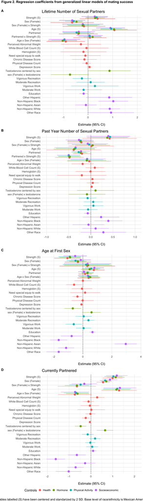

Lifetime number of partners control models

Standardized regression coefficents from generalized linear models

| **Characteristic** | Socioeconomic **log(IRR)**<sup>1</sup> | Socioeconomic **95% CI**<sup>1</sup> | Socioeconomic **p-value** | Health **log(IRR)**<sup>1</sup> | Health **95% CI**<sup>1</sup> | Health **p-value** | Hormone **log(IRR)**<sup>1</sup> | Hormone **95% CI**<sup>1</sup> | Hormone **p-value** | Physical Activity **log(IRR)**<sup>1</sup> | Physical Activity **95% CI**<sup>1</sup> | Physical Activity **p-value** |
| --- | --- | --- | --- | --- | --- | --- | --- | --- | --- | --- | --- | --- |
| age_centered | 0.91 | 0.33, 1.5 | 0.012 | 1.1 | 0.16, 2.0 | 0.033 | 1.1 | 0.50, 1.6 | 0.002 | 0.94 | 0.51, 1.4 | 0.002 |
| sex |  |  |  |  |  |  |  |  |  |  |  |  |
| male | — | — |  | — | — |  | — | — |  | — | — |  |
| female | -0.64 | -1.2, -0.11 | 0.028 | -0.64 | -1.5, 0.24 | 0.10 | -0.47 | -0.72, -0.21 | 0.003 | -0.58 | -0.94, -0.23 | 0.007 |
| strength_centered | 0.27 | -0.26, 0.81 | 0.2 | 0.39 | -0.33, 1.1 | 0.2 | 0.29 | -0.11, 0.68 | 0.13 | 0.35 | -0.09, 0.78 | 0.10 |
| partnered |  |  |  |  |  |  |  |  |  |  |  |  |
| FALSE | — | — |  | — | — |  | — | — |  | — | — |  |
| TRUE | -0.38 | -1.0, 0.28 | 0.2 | -0.39 | -1.2, 0.40 | 0.2 | -0.37 | -1.0, 0.24 | 0.2 | -0.46 | -1.0, 0.10 | 0.091 |
| edu | -0.18 | -0.35, -0.01 | 0.044 |  |  |  |  |  |  |  |  |  |
| race |  |  |  |  |  |  |  |  |  |  |  |  |
| MexicanAmerican | — | — |  |  |  |  |  |  |  |  |  |  |
| OtherHispanic | 0.86 | -0.08, 1.8 | 0.063 |  |  |  |  |  |  |  |  |  |
| NonHispanicWhite | 0.88 | 0.46, 1.3 | 0.005 |  |  |  |  |  |  |  |  |  |
| NonHispanicBlack | 1.0 | 0.43, 1.6 | 0.009 |  |  |  |  |  |  |  |  |  |
| NonHispanicAsian | -0.09 | -0.52, 0.35 | 0.6 |  |  |  |  |  |  |  |  |  |
| OtherRace | 0.93 | 0.00, 1.9 | 0.050 |  |  |  |  |  |  |  |  |  |
| age_centered * sex |  |  |  |  |  |  |  |  |  |  |  |  |
| age_centered * female | -1.0 | -1.6, -0.31 | 0.015 | -0.90 | -1.7, -0.12 | 0.035 | -1.0 | -1.6, -0.44 | 0.004 | -1.0 | -1.5, -0.46 | 0.004 |
| sex * strength_centered |  |  |  |  |  |  |  |  |  |  |  |  |
| female * strength_centered | -0.21 | -1.0, 0.62 | 0.5 | -0.16 | -1.0, 0.70 | 0.6 | -0.22 | -0.81, 0.38 | 0.4 | -0.19 | -0.85, 0.47 | 0.5 |
| strength_centered * partnered |  |  |  |  |  |  |  |  |  |  |  |  |
| strength_centered * TRUE | 0.06 | -0.48, 0.59 | 0.8 | 0.08 | -0.60, 0.75 | 0.7 | 0.19 | -0.18, 0.56 | 0.3 | 0.07 | -0.38, 0.52 | 0.7 |
| perceived_abnormal_weight |  |  |  |  |  |  |  |  |  |  |  |  |
| FALSE |  |  |  | — | — |  |  |  |  |  |  |  |
| TRUE |  |  |  | -0.29 | -1.1, 0.52 | 0.3 |  |  |  |  |  |  |
| whitebloodcell_centered |  |  |  | -0.06 | -1.0, 0.83 | 0.8 |  |  |  |  |  |  |
| hemoglobin_centered |  |  |  | -0.19 | -1.1, 0.74 | 0.6 |  |  |  |  |  |  |
| special_equipment |  |  |  |  |  |  |  |  |  |  |  |  |
| FALSE |  |  |  | — | — |  |  |  |  |  |  |  |
| TRUE |  |  |  | -0.11 | -0.73, 0.51 | 0.6 |  |  |  |  |  |  |
| chronic_disease_score |  |  |  | -0.15 | -0.65, 0.36 | 0.4 |  |  |  |  |  |  |
| physical_disease_count |  |  |  | -0.06 | -0.23, 0.12 | 0.4 |  |  |  |  |  |  |
| depression |  |  |  | 0.06 | -0.04, 0.16 | 0.14 |  |  |  |  |  |  |
| testosterone_sex_centered |  |  |  |  |  |  | 0.87 | 0.01, 1.7 | 0.048 |  |  |  |
| sex * testosterone_sex_centered |  |  |  |  |  |  |  |  |  |  |  |  |
| female * testosterone_sex_centered |  |  |  |  |  |  | -0.73 | -1.5, 0.04 | 0.060 |  |  |  |
| vigorous_rec |  |  |  |  |  |  |  |  |  | -0.25 | -0.62, 0.13 | 0.2 |
| moderate_rec |  |  |  |  |  |  |  |  |  | 0.11 | -0.47, 0.68 | 0.7 |
| vigorous_work |  |  |  |  |  |  |  |  |  | 0.28 | -0.68, 1.2 | 0.5 |
| moderate_work |  |  |  |  |  |  |  |  |  | -0.18 | -0.93, 0.57 | 0.6 |

<sup>1</sup> IRR = Incidence Rate Ratio, CI = Confidence Interval

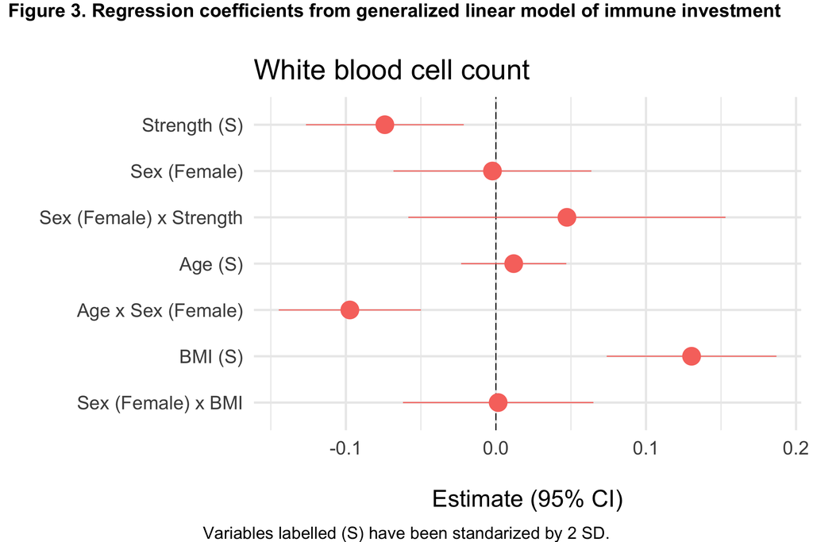

Regression coefficients for predictors of WBC count in men and women 18-59, exact model from lassek and gaulin

| **Variable** | **Beta (SE)**<sup>1,2</sup> |
| --- | --- |
| Age | 0.01 (0.016) |
| Sex |  |
| male | — |
| female | 0.00 (0.030) |
| Grip strength | -0.07* (0.024) |
| BMI | 0.13*** (0.025) |
| Age * Sex |  |
| Age * female | -0.10** (0.021) |
| Sex * Grip strength |  |
| female * Grip strength | 0.05 (0.047) |
| Sex * BMI |  |
| female * BMI | 0.00 (0.028) |

<sup>1</sup> *p<0.05; **p<0.01; ***p<0.001  
<sup>2</sup> SE = Standard Error

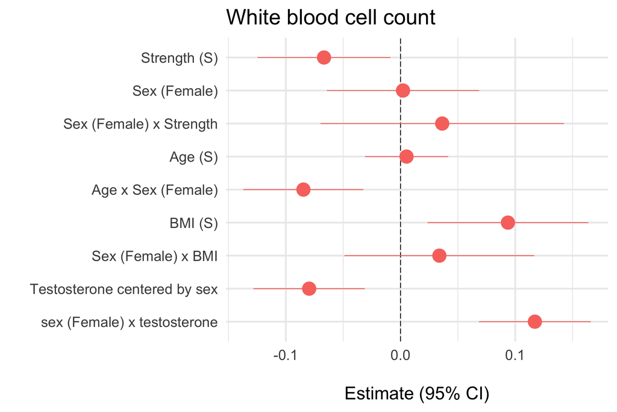

### Discussion

Under what conditions would we still expect sexual dimorphism in strength even when it is positively associated with reproductive success for both males and females?

Association between strength and fitness for women